# Project 1 - Happy Moment Analysis

# Xinzhu Wang(xw2581)

What makes people happy? It is always a topic deserving exploration and analysis. In the following content, I will discuss the differences of happy moments between male and female, as well as the happy moments for past 24 hours versus 3 months. Also nine different topics of happy moments for each gender will be included. Hope these analysis will provide people a better undersatnd of happiness and how happy moments spark in everyone’s daily life.

# I. Import and Clean data

First, I import the original dataset called hm_orig generated by the test-processing.rmd file. Then, the hm dataset is the one I have cleaned the stopwords which is more readable and more convinent to do analysis. Here it shows 6 rows of the data in hm dataset.

```r
hm_orig <- read.csv("~/Documents/GitHub/Spring2019-Proj1-EvelynWangxz/output/processed_moments.csv")
hm <- read.csv("~/Documents/GitHub/Spring2019-Proj1-EvelynWangxz/output/processed_moments_new.csv")
hm_demo <- read.csv("~/Documents/GitHub/Spring2019-Proj1-EvelynWangxz/data/data/demographic.csv")
```

```r
head(hm,6)
```

|  | hmid | wid | reflection_period | original_hm | cleaned_hm | modified | num_sentence | ground_truth_category | predicted_category | id | text |
| --- | --- | --- | --- | --- | --- | --- | --- | --- | --- | --- | --- |
| 1 | 27673 | 2053 | 24h | I went on a successful date with someone I felt sympathy and connection with. | I went on a successful date with someone I felt sympathy and connection with. | TRUE | 1 | NA | affection | 1 | successfully date sympathy connected |
| 2 | 27674 | 2 | 24h | I was happy when my son got 90% marks in his examination | I was happy when my son got 90% marks in his examination | TRUE | 1 | NA | affection | 2 | son marks examination |
| 3 | 27675 | 1936 | 24h | I went to the gym this morning and did yoga. | I went to the gym this morning and did yoga. | TRUE | 1 | NA | exercise | 3 | gym morning yoga |
| 4 | 27676 | 206 | 24h | We had a serious talk with some friends of ours who have been flaky lately. They understood and we had a good evening hanging out. | We had a serious talk with some friends of ours who have been flaky lately. They understood and we had a good evening hanging out. | TRUE | 2 | bonding | bonding | 4 | talked friend flaky understood evening hang |
| 5 | 27677 | 6227 | 24h | I went with grandchildren to butterfly display at Crohn Conservatory\n | I went with grandchildren to butterfly display at Crohn Conservatory\n | TRUE | 1 | NA | affection | 5 | grandchildren butterfly display crohn conservatory |
| 6 | 27678 | 45 | 24h | I meditated last night. | I meditated last night. | TRUE | 1 | leisure | leisure | 6 | meditation night |

```r
hm_m <- filter(hm,hm$wid %in% filter(hm_demo,gender == "m")$wid)
hm_f <- filter(hm,hm$wid %in% filter(hm_demo,gender == "f")$wid)
```

Below are some sample code used to clean stopwords. Actually it has been finished in Text_Processing_new.rmd file. I made some deletion in stopwords according to the results of counting the frequencies of each word, like day, time, finally which are uncessary and meaningless to apeear in the following analysis.

```r
#data("stop_words")

#word <- c("happy","ago","yesterday","lot","today","months","month",
#                 "happier","happiest","last","week","past","day","time","finally","feel","enjoyed","moment","nice","favorite","hours","weekend","called","days","enjoy","excited","didnt")

#stop_words <- stop_words %>%
#  bind_rows(mutate(tibble(word), lexicon = "updated"))
```

# II. Explorative Data Analysis

1. WordCloud for data before deleteing more stop words. In this wordcloud, you can observe that the most common word is “frind”, along with some words like “day”, “time”, “family” and “home”. However, it is very obvious that words like “day” and “time” are meaningless. They will affect the analysis results and cover the real meaningful words. So I coustomize the stopwords list and delete them.

```r
corpus_orig <- VCorpus(VectorSource(hm_orig$text))
tm_orig <- TermDocumentMatrix(corpus_orig)
tm.tidy_orig <- tidy(tm_orig)
tm1_orig <- summarise(group_by(tm.tidy_orig, term), sum(count))
```

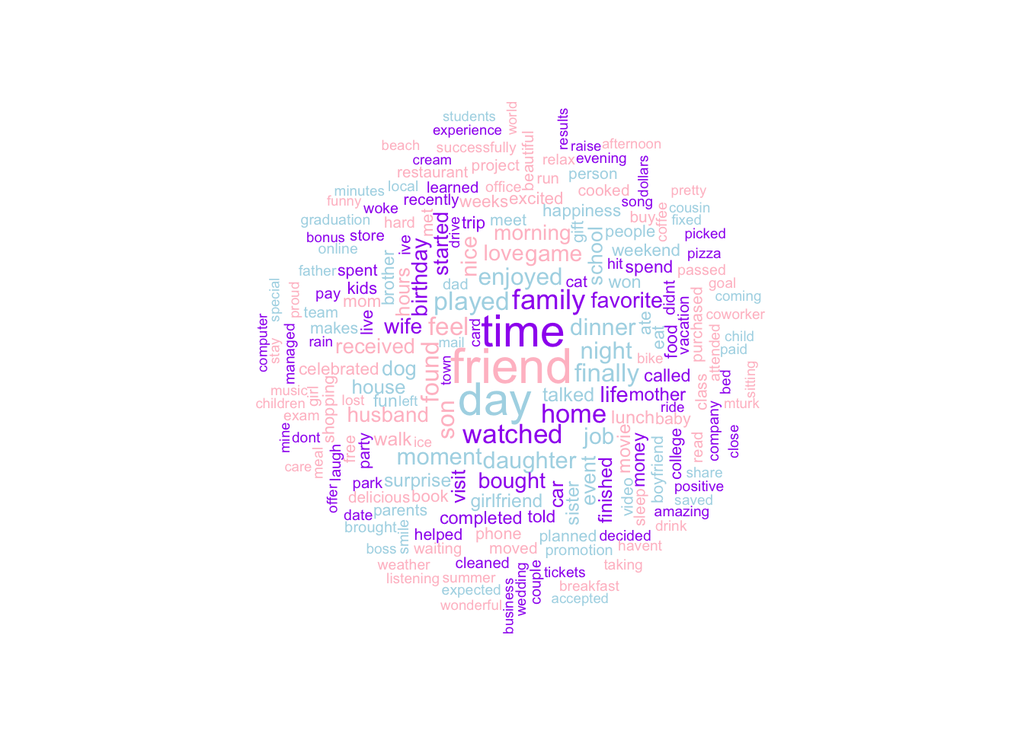

```r
wordcloud(tm1_orig$term, tm1_orig$`sum(count)`, scale=c(2,0.5), max.words=200, min.freq=1, random.order=FALSE, rot.per=0.3, use.r.layout=T, random.color=T, colors=c("purple","pink","lightblue"))
```

2. After deleting the custom stopwords, I finalize a brand-new wordcloud. It shows the frequency of each word when you click on the word. In the wordcloud, “friend” is still the most frequent word. There are also some words like “home”, “family”, “son”, “watched”, “game” and “birthday” which illustrate the topic of these happy moments might be related to family and enjoyment activities.

```r
corpus <- VCorpus(VectorSource(hm$text))
tm <- TermDocumentMatrix(corpus)
tm.tidy <- tidy(tm)
tm1 <- summarise(group_by(tm.tidy, term), sum(count))
```

```r
tm1 <- data.frame(tm1)
tm.red <- head(tm1[order(tm1[,2],decreasing = T),],100)
```

```r
wordcloud2(tm.red, size=0.7,color='random-light',fontWeight = 'bold',minRotation = -pi/3,maxRotation = pi/3,rotateRatio = 0.8)
```

[interactive chart not shown]

3. After having an overall analysis of the most frequent words in happy moments. I would like to focus on the differences between male and female. Two bar plots below is a comparsion of the top 10 words for male and female. For both male and female, “friend” is the most reliable source of happiness. While, the other words in the top 10 for male show that male are catching happiness more from games, watchting and playing activities which is very different from female’s. For female, they are more likely to get happiness from family like their hubsand, son and daughter. It is barely to see enjoyment words like “games” and “played” in female’s top 10 lists. This observation is shown more clearly in the third barplot which is a directly comparsion of top 20 words between male and female.

```r
m.tidy <- tidy(TermDocumentMatrix(VCorpus(VectorSource(hm_m$text))))
m <- summarise(group_by(m.tidy, term), sum(count))
m <- data.frame(m)
m.red <- head(m[order(m[,2],decreasing = T),],10)
```

```r
p1 <- ggplot(m.red, aes(x =reorder(m.red$term,m.red$sum.count.),y = m.red$sum.count.)) + geom_bar(stat = "identity", fill = "lightblue") + coord_flip() + xlab("male") + ylab("term")
```

```r
f.tidy <- tidy(TermDocumentMatrix(VCorpus(VectorSource(hm_f$text))))
f <- summarise(group_by(f.tidy, term), sum(count))
f <- data.frame(f)
f.red <- head(f[order(f[,2],decreasing = T),],10)
```

```r
p2 <- ggplot(f.red, aes(x =reorder(term,sum.count.),y = sum.count.)) + geom_bar(stat = "identity", fill = "pink") + coord_flip() + xlab("female") + ylab("term")
```

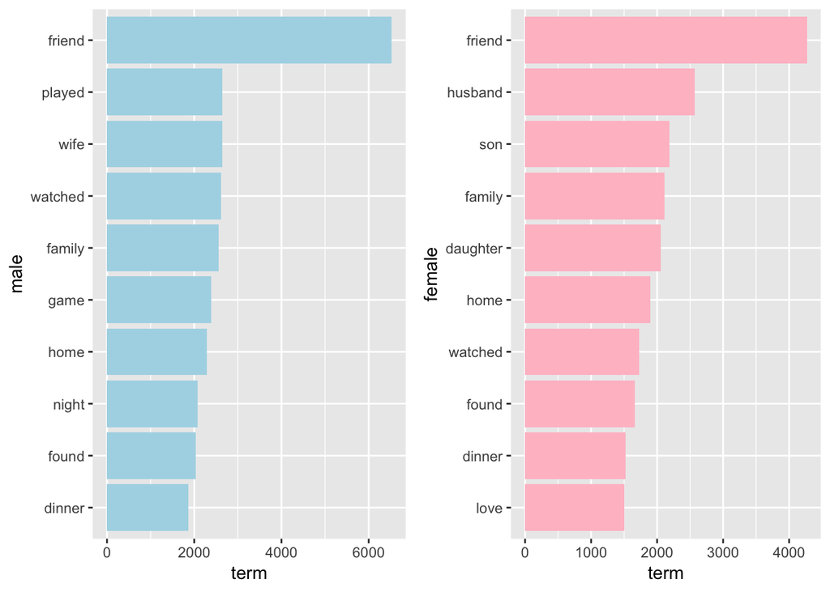

```r
grid.arrange(p1, p2, nrow = 1, ncol = 2)
```

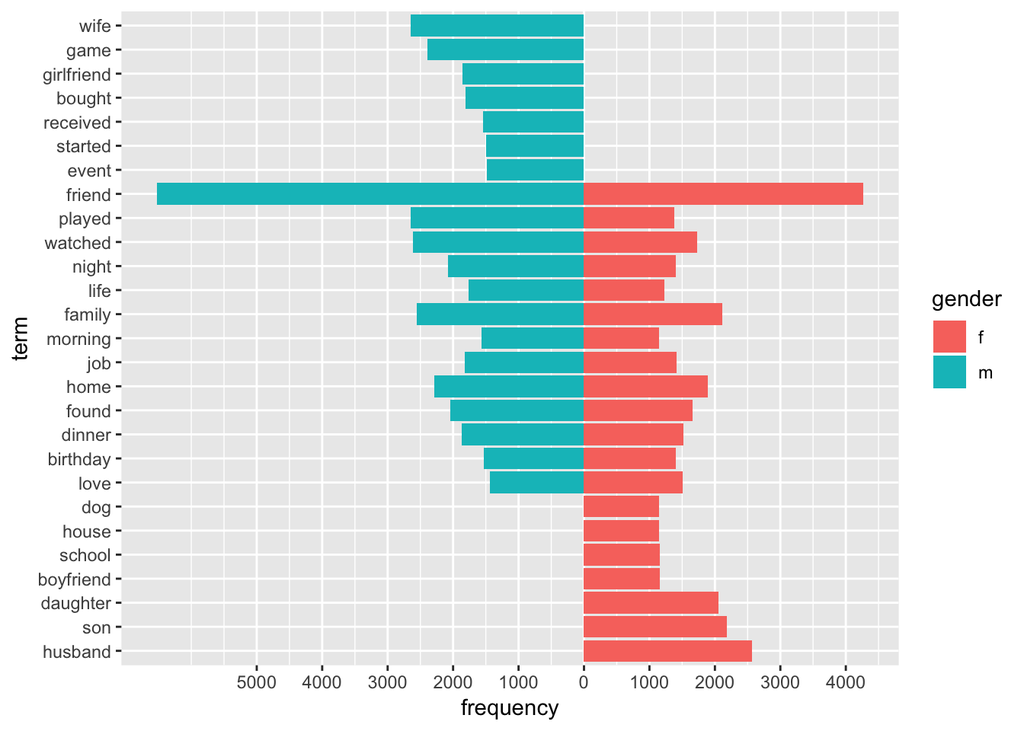

```r
m.red <- head(m[order(m[,2],decreasing = T),],20)
f.red <- head(f[order(f[,2],decreasing = T),],20)
m.red$sum.count. <- m.red$sum.count.*(-1)
temp1 <- rbind(m.red,f.red)
temp2 <- c(rep("m",20),rep("f",20))
temp1$gender <- temp2
ggplot(data = temp1, aes(x = reorder(temp1$term, -temp1$sum.count.), y = temp1$sum.count., group = gender, fill = gender)) + geom_bar(position = "stack", stat = "identity") + scale_y_continuous(labels = c(5000,4000,3000,2000,1000,0,1000,2000,3000,4000,5000), breaks = seq(-5000,5000,1000)) + xlab("term") + ylab("frequency") + coord_flip()
```

# III. LDA Analysis

1. Using LDA to show the top 10 frequent words of nine different topics of happy moments between male and female. After analyzing the top 10/20 frequent words for both male and female, I would like to show you what kind of topic these words could build. It will illustrate the buildup of happy moments for each gender. For male, accroding to the plot below, I would like to divide the words in nine topics which are “family”, “event”, “entertainment”, “life”, “food”, “shopping”, “school”, “archievement”, “work”. This result is based on the top 10 frequent words in each topic. For example, in one topic, there are words including “game”, “played”, “watched” and “video” which indicate this topic should be entertainment. Doing the same thing to the left will get their topics. These nine topics are pretty reasonable and basically overlap people’s daily lives.

```r
m.data <- hm_m %>% group_by(wid) %>% summarise(text = paste(text, collapse = " "))
m.lda <- LDA(DocumentTermMatrix(Corpus(VectorSource(m.data$text))), k = 9, control = list(seed = 2000))
m.lda.tidy <- tidy(m.lda)
m.top10 <- m.lda.tidy %>% group_by(topic) %>% top_n(10, beta) %>% ungroup() %>% arrange(topic, -beta)
```

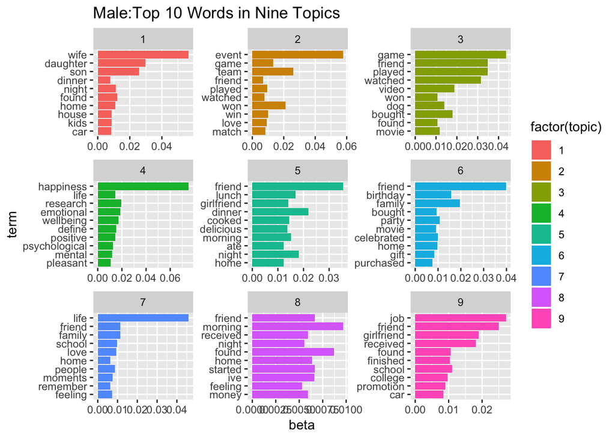

```r
plot_m <- m.top10 %>%mutate(term = reorder(term, beta)) %>% ggplot(aes(term, beta, fill = factor(topic))) +geom_bar(stat = "identity", show.legend = T) +facet_wrap(~ topic, scales = "free") +coord_flip() + ggtitle("Male:Top 10 Words in Nine Topics")
plot_m
```

```r
f.data <- hm_f %>% group_by(wid) %>% summarise(text = paste(text, collapse = " "))
f.lda <- LDA(DocumentTermMatrix(Corpus(VectorSource(f.data$text))), k = 9, control = list(seed = 2000))
f.lda.tidy <- tidy(f.lda)
f.top10 <- f.lda.tidy %>% group_by(topic) %>% top_n(10, beta) %>% ungroup() %>% arrange(topic, -beta)
```

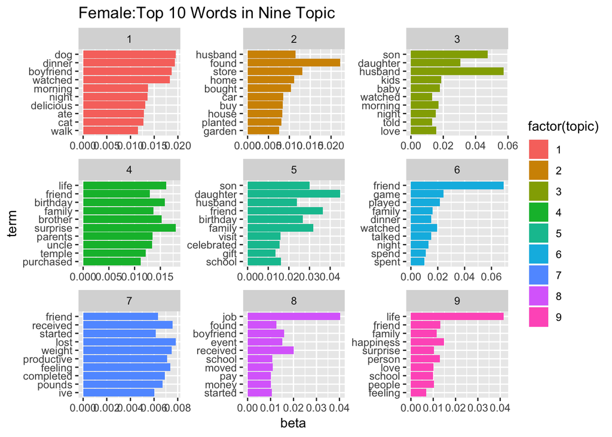

```r
plot_f <- f.top10 %>%mutate(term = reorder(term, beta)) %>% ggplot(aes(term, beta, fill = factor(topic))) +geom_bar(stat = "identity", show.legend = T) +facet_wrap(~ topic, scales = "free") +coord_flip() + ggtitle("Female:Top 10 Words in Nine Topic")
plot_f
```

# IV. Time Effect Analysis

Time is always an effective influence to the content of happy moments. Therefore, I would like to analyze what is the shift between past 24 hours and 3 months in each gender.

1. Differences of happy moments between male and female for the past 24 hours

```r
hm.m24 <- hm_m[hm_m$reflection_period=="24h",]
hm.f24 <- hm_f[hm_f$reflection_period=="24h",]
hm.m24$gender <- "m"
hm.f24$gender <- "f"
hm24 <- rbind(hm.m24,hm.f24)
hm24_plot <- ggplot(hm24, aes(predicted_category, fill = gender)) + geom_bar() + ggtitle("Predicted Category Distribution for 24 hours") +coord_flip()
```

2. Differences of happy moments between male and female for the past 3 months

```r
hm.m3 <- hm_m[hm_m$reflection_period=="3m",]
hm.f3 <- hm_m[hm_f$reflection_period=="3m",]
hm.m3$gender <- "m"
hm.f3$gender <- "f"
hm3 <- rbind(hm.m3,hm.f3)
hm3_plot <- ggplot(hm3, aes(predicted_category, fill = gender)) + geom_bar() + ggtitle("Predicted Category Distribution for 3 months") +coord_flip()
```

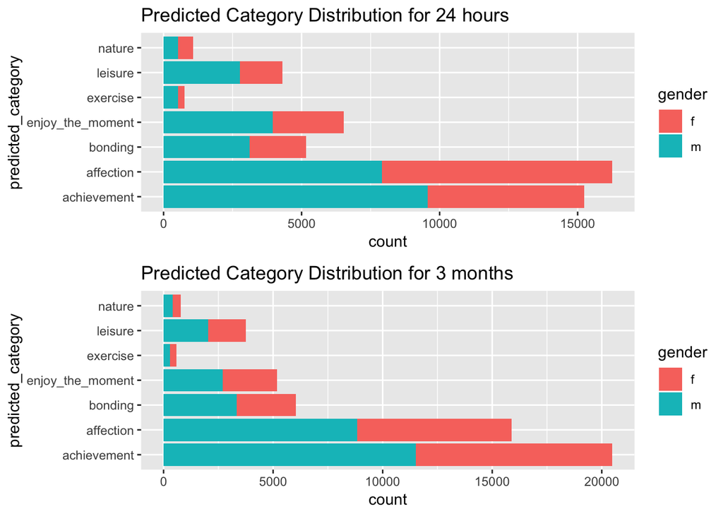

```r
grid.arrange(hm24_plot, hm3_plot, nrow = 2, ncol = 1)
```

3. HeatMap The heatmap below is a more direct way to compare time effect on each category between male and female. The grid with deeper color indicates the more important position of that category in happy moments. The affection and archievement are very outstanding compared with others. The exercise is very cheerless and only has a little proportion for male in past 24 hours. It can slightly illustrate that male cares more about exercise than female does.

```r
hm.m24$time <- "m24"
hm.f24$time <- "f24"
hm.m3$time <- "m3"
hm.f3$time <- "f3"
hm.time <- rbind(hm.m24,hm.f24,hm.m3,hm.f3)

prop <- function(data){
affection <- data[data$predicted_category=="affection",]
a <- dim(affection)[1]/nrow(data)
leisure <- data[data$predicted_category=="leisure",]
l <- dim(leisure)[1]/nrow(data)
enjoy_the_moment <- data[data$predicted_category=="enjoy_the_moment",]
e <- dim(enjoy_the_moment)[1]/nrow(data)
achievement <- data[data$predicted_category=="achievement",]
ach <- dim(achievement)[1]/nrow(data)
bonding <- data[data$predicted_category=="bonding",]
b <- dim(bonding)[1]/nrow(data)
nature <- data[data$predicted_category=="nature",]
n <- dim(nature)[1]/nrow(data)
exercise <- data[data$predicted_category=="exercise",]
ex <- dim(exercise)[1]/nrow(data)
df <- data.frame(c(a,l,e,ach,b,n,ex))
}
d1 <- prop(hm.f24)
d2 <- prop(hm.m24)
d3 <- prop(hm.f3)
d4 <- prop(hm.m3)
d11 <- rbind(d1,d2,d3,d4)
d22 <- c(rep("f24",7),rep("m24",7),rep("f3",7),rep("m3",7))
d33 <- rep(c("affection","leisure","enjoy_the_moment","achievement","bonding","nature","exercise"),4)
df <- data.frame(d11,d22,d33)
colnames(df) <- c("prop","time","topic")
```

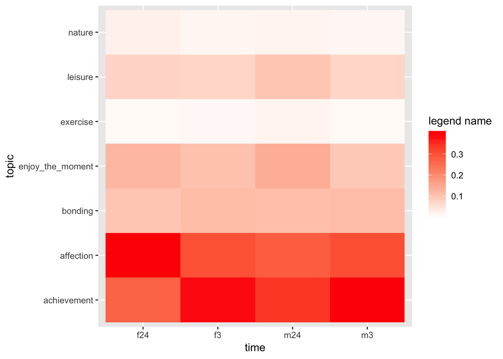

```r
ggplot(df, aes(x=time,y=topic,fill=prop)) + geom_tile() + scale_fill_gradient2('legend name', low = 'blue', high = 'red')
```

# V. Conclusion